# Introduction to distance sampling

David L Miller

### Overview

Here we'll look at:

- Quadrats to line transects
- Simple estimates of abundance
- Why is detectability important?
- What is a detection function?
- First look at fitting models in R

### How many animals are there? (500!)

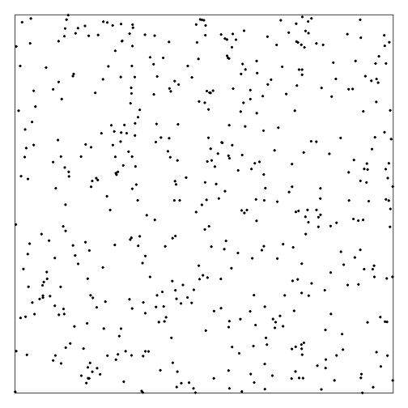

### General strategy

- Take a sample in some fixed areas
- Find density/abundance in *covered area*
- Multiply up to get abundance

### General strategy (What did we assume?)

- Take a sample in some fixed areas
  - *Sample is representative*
- Find density/abundance in *covered area*
  - *Estimator is “good”*
- Multiply up to get abundance
  - *Uniform distribution outside covered area*

### Plot sampling

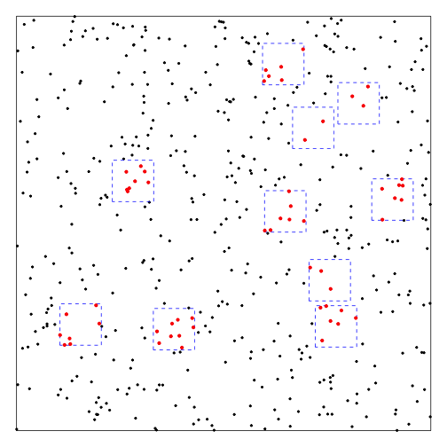

- Surveyed 10 quadrats (each \( 0.1^2 \) units)
  - Total covered area \( a=10 * 0.1^2 = \) 0.1
- Saw \( n= \) 59 animals
- Estimated density \( \hat{D}=n/a= \) 590
- Total area \( A=1 \)
- Estimated abundance \( \hat{N}= \) 590

### Strip transect

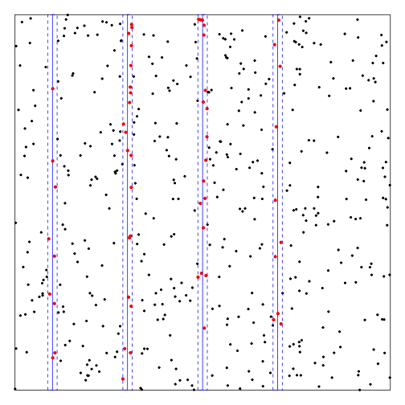

- Surveyed 4 lines (each \( 1*0.025 \) units)
  - Total covered area \( a=4*1*0.025 = \) 0.1
- Saw \( n= \) 57 animals
- Estimated density \( \hat{D}=n/a= \) 570
- Total area \( A=1 \)
- Estimated abundance \( \hat{N}= \) 570

## Detectability

### Detectability matters!

- We've assumed certain detection so far
- This rarely happens IRL
- Distance to the line is important
  - (Other things too, more on that later)
  - Detectability should decrease with increasing distance

### Recording distances is more efficient

- Plots: what if an animal is *just* outside the box?
- Strips: what if an animal is *just* outside the strip?
- Line transects: record **everything**, then discard later
  - Decide strip width (*truncation distance*) later

### Detection as a function of distance

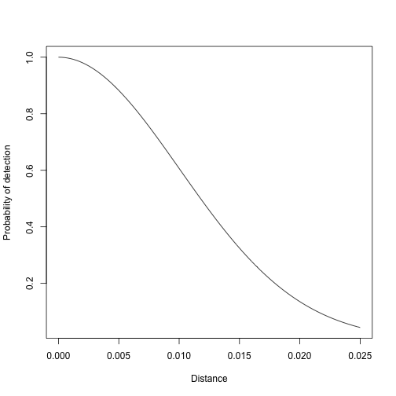

- Model probability of detection, given distance
- Fit models for the curve
- Derive a probability of detection from this model

### Line transect

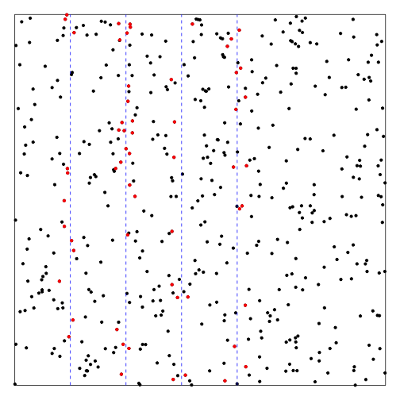

### Line transects - distances

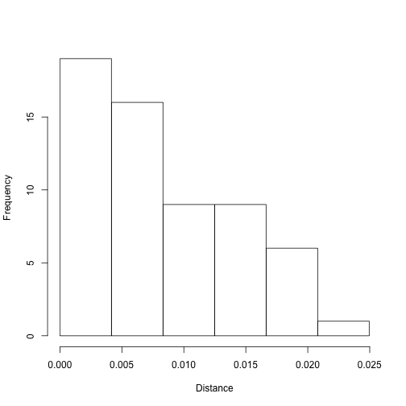

- Now we recorded distances, what do they look like?
- Drop-off in # observations w. increasing distance

## "You should model that"

### Detection function

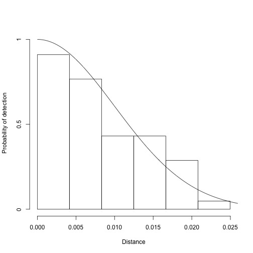

### Using distance information

- Detection function: \( \mathbb{P}(\text{ detection } \vert \text{ at distance } x) \)
- Integrate out the conditioning \( \Rightarrow \mathbb{P}(\text{ detection }) = \hat{p} \)
- “Inflate” \( n \) by \( \hat{p} \) to estimate abundance

### Summary: line transects

- Efficient survey design
- Relax the assumption of perfect detection
- More information = better inference

## Assumptions

### Assumptions

1. Animals are distributed independent of lines
2. On the line, detection is certain
3. Distances are recorded correctly
4. Animals don't move before detection

### Animals are distributed independent of lines

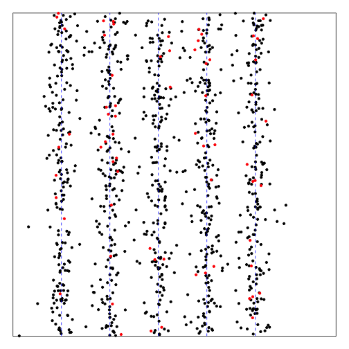

- When transects follow features
- Difficult to work out detectability vs. distribution

### On the line, detection is certain

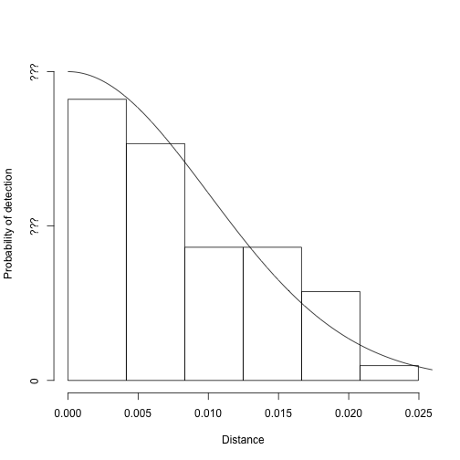

- Perception bias
- Availability bias
- Don't know \( y \) axis scale

### Distances are recorded correctly

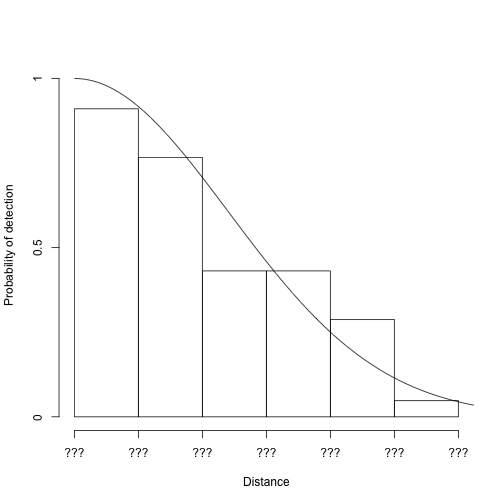

- Measurement error
- Don't know \( x \) axis scale
- This can be systematic

### Animals don't move before detection

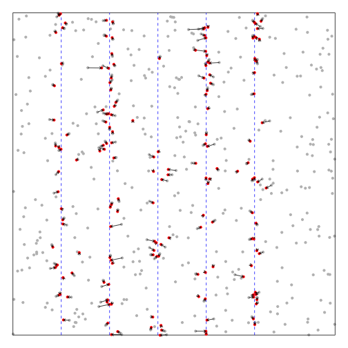

- Animals can be attracted or repelled
- Either leads to problems with distribution wrt line and measurement error

## Detection functions

### What are detection functions?

- Model \( \mathbb{P}\left( \text{detection } \vert \text{ animal at distance } x \right) \)
- (Hence the integration)
- Many different forms, depending on the data
- All share some characteristics

### Detection function assumptions

- Have a “shoulder”
  - *we see things nearby easily*
- Monotonic decreasing
  - *never increasing with increasing distance*
- “Model robust”
  - *lots of forms/flexible models*
- “Pooling robust”
  - *individual heterogeneity averages out*
- “Efficient”
  - *models don't need lots of parameters*

### Possible detection functions

- There are many options
- A restricted set we'll cover in this course…
  - Half-normal
  - Hazard-rate
  - adjustments to the above

### Half-normal detection functions

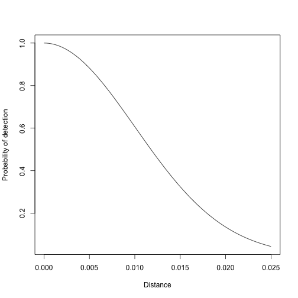

### Hazard-rate detection functions

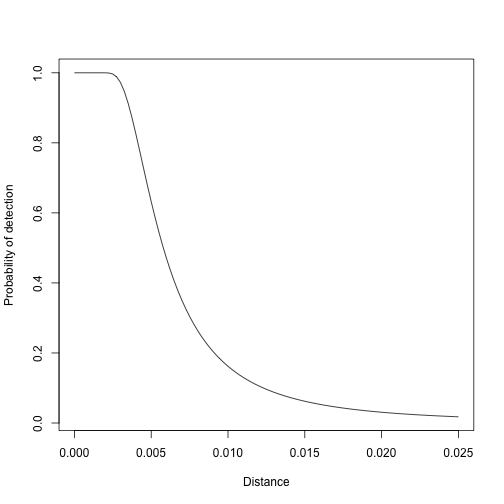

### Adjustment terms

- These models are flexible
- What about adding more flexibilty by “adjusting” them
- Options:
  - Cosine series
  - Polynomials
  - Hermite polynomials
- Add extra flexibility

## Okay, but how can we actually do this?

### Modelling strategy

- Pick some formulations, fit models
- Evaluate if they violate the assumptions
- Check models
- Select models
- Estimate \( \hat{N} \)

### Fitting detection functions (in R!)

- Using the package `Distance`
- Need to have data setup a certain way
  - At least columns called `object`, `distance`

```r
library(Distance)
df_hn <- ds(distdata, truncation=6000, adjustment = NULL)
df_hr <- ds(distdata, truncation=6000, key="hr", adjustment = NULL)
```

### Model summary

```r
summary(df_hn)
```

```
Summary for distance analysis
Number of observations :  132
Distance range         :  0  -  6000

Model : Half-normal key function
AIC   : 2252.06

Detection function parameters
Scale Coefficients:
            estimate         se
(Intercept) 7.900732 0.07884776

                       Estimate          SE         CV
Average p             0.5490484  0.03662569 0.06670757
N in covered region 240.4159539 21.32287580 0.08869160
```

### Plotting models

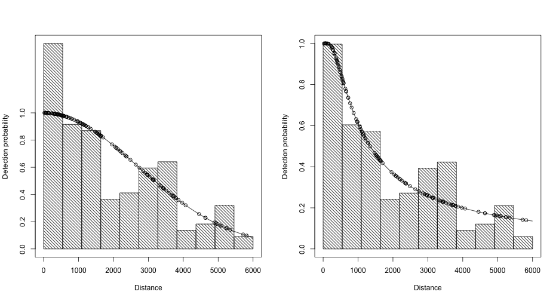

### Truncation

- We set `truncation=6000`, why?
- Remove observations in the tail of the distribution
- Such observation lead to bad model fit ***

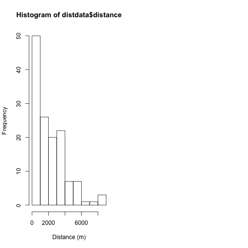

## Recap

### Distance sampling

- More efficient sampling
- Collect additional information
- Estimate detection
- Use \( \mathbb{P}(\text{detection}) \) to correct counts

### What's next?

- Model checking and selection
- Estimating abundance in R
- Stratification
- What else affects detectability?